# Dia 5: Procesaiento de amplicones de COX1

# Preparación

## Corregir problemas con WSL

```python
# Reestablecer contraseña en WSL

# Abrir CMD en windows

wsl -d Ubuntu -u root

passwd <username>

# Agregar usuario a lista de administradores

# Abrir CMD en windows

wsl -u root

usermod -aG sudo <username>
```

## Preparar y descargar datos

- Iniciar Ubuntu
- Activar ambiente `conda activate jupyter`
- Iniciar jupter lab `jupyter lab --no-browser`

```python
# crear directorio dia5
mkdir dia5

# moverse
cd dia5
```

- Descargar archivo de drive
- Subir al directorio dia5

```python
# revisar contenidos
unzip -l drive-download-20250319T224138Z-001.zip

# crear directorio porque no hay directorio en el zip
mkdir reads

# descomprimir
unzip -d reads drive-download-20250319T224138Z-001.zip
```

## Flujo de trabajo en Snakemake

Desde la terminal en jupyter lab

```python
# instalar git
sudo apt-get intall git

# clonar coiner
git clone https://github.com/miferg/coiner.git

# moverse al directorio
cd coiner

# EXPLORAR

# instalar snakemake
conda create -q -y -n snakemake -c conda-forge -c bioconda snakemake

# activar
conda activate snakemake

# ejecutar
snakemake --cores 4 --use-conda --config querydir="/home/userXX/dia5/reads/"
outdir="/home/userXX/dia5/reads_coiner_out/" splitkey="__COI_R" threads_per_job=2

## tal vez haga falta
# conda config --set channel_priority flexible

# crear DAGs
conda install -q -y -c conda-forge graphviz

snakemake --rulegraph --cores 4 --use-conda --config querydir="/home/userXX/dia5/reads/" outdir="/home/userXX/dia5/reads_coiner_out/" splitkey="__COI_R" threads_per_job=2 | dot -Tsvg > ../coiner_rule_dag.svg

snakemake --dag --cores 4 --use-conda --config querydir="/home/userXX/dia5/reads/" outdir="/home/userXX/dia5/reads_coiner_out/" splitkey="__COI_R" threads_per_job=2 | dot -Tsvg > ../coiner_full_dag.svg

snakemake --filegraph --cores 4 --use-conda --config querydir="/home/userXX/dia5/reads/" outdir="/home/userXX/dia5/reads_coiner_out/" splitkey="__COI_R" threads_per_job=2 | dot -Tsvg > ../coiner_file_dag.svg
```

## Filtrar secuencias con DARN

En windows

- Crear una carpeta dentro de "C:" llamada "shared" y dentro de ella, otra llamada "atlas_coi"
- Mover el archivo `coiner.fna` a la carpeta "atlas_coi"
- Lanzar Docker
- Bajar la imagen de darn desde la app buscando "hariszaf/darn"
- Cerrar app
- Abrir la línea de comandos: teclear inicio, escribir "cmd" y dar Enter
- Lanzar el contenedor y montar la carpeta "atlas_coi": `docker run --rm -it -v C:\shared\atlas_coi:/mnt hariszaf/darn`
- Ejecutar darn: `./darn.sh -s /mnt/coiner.fna -t 4`
- Salir del contenedor: `exit`
- Revisar Krona
- Cerrar la terminal
- Cerrar Docker
- "Subir" el archivo "darn_coin_eukaryota_assignments.fasta" de la carpeta "final_outcome" al directorio dia5 en jupyter

# Anotar con SINTAX

## Instalar ambiente para vsearch

A partir de este proceso vamos a correr código de la línea de comandos desde el jupyter notebook. Esto se logra agregando el símbolo de exclamación "!" al inicio de la celda. Importante: El código que se ejecuta de esta forma no tiene memoria, es decir funciona como si abriéramos una terminal nueva en cada celda.

```python
! conda create -q -y -n vsearch -c bioconda vsearch
```

```
Channels:
 - bioconda
 - defaults
Platform: linux-64
Solving environment: ...working... done

## Package Plan ##

  environment location: /home/miferg/.conda/envs/vsearch

  added / updated specs:
    - vsearch


The following NEW packages will be INSTALLED:

  _libgcc_mutex      pkgs/main/linux-64::_libgcc_mutex-0.1-main
  _openmp_mutex      pkgs/main/linux-64::_openmp_mutex-5.1-52_gnu
  bzip2              pkgs/main/linux-64::bzip2-1.0.8-h5eee18b_6
  libgcc             pkgs/main/linux-64::libgcc-15.2.0-h69a1729_8
  libgcc-ng          pkgs/main/linux-64::libgcc-ng-15.2.0-h166f726_8
  libstdcxx          pkgs/main/linux-64::libstdcxx-15.2.0-h39759b7_8
  libzlib            pkgs/main/linux-64::libzlib-1.3.2-h47b2149_0
  vsearch            bioconda/linux-64::vsearch-2.31.0-hd2be7a0_0


Preparing transaction: ...working... done
Verifying transaction: ...working... done
Executing transaction: ...working... done
```

## Anotar

```python
! wget -nv https://www.reference-midori.info/download/Databases/GenBank272_2026-06-07/SINTAX_sp/longest/MIDORI2_LONGEST_NUC_SP_GB272_CO1_SINTAX.fasta.gz
```

```
2026-08-06 11:10:26 URL:https://www.reference-midori.info/download/Databases/GenBank272_2026-06-07/SINTAX_sp/longest/MIDORI2_LONGEST_NUC_SP_GB272_CO1_SINTAX.fasta.gz [95861380/95861380] -> "MIDORI2_LONGEST_NUC_SP_GB272_CO1_SINTAX.fasta.gz" [1]
```

```python
! conda run -n vsearch vsearch --sintax reads_coiner_out/coiner.fna \
    --db MIDORI2_LONGEST_NUC_SP_GB272_CO1_SINTAX.fasta.gz \
    --sintax_cutoff 0.8 \
    --tabbedout coi__midori2.sintax_0.8.tsv \
    --threads 4 \
    --no_progress
```

```
vsearch v2.31.0_linux_x86_64, 503.6GB RAM, 256 cores
https://github.com/torognes/vsearch

Reading file MIDORI2_LONGEST_NUC_SP_GB272_CO1_SINTAX.fasta.gz 100%
575621298 nt in 854416 seqs, min 100, max 2298, avg 674
Counting k-mers 100%
Creating k-mer index 100%
Classifying sequences 100%
Classified 549 of 549 sequences (100.00%)
```

# Crear tabla

```python
import pandas as pd
import numpy as np
```

## Procesar taxonomía

```python
sintax = pd.read_csv('coi__midori2.sintax_0.8.tsv', sep='\t', header=None)
sintax.columns = ['id','full_path','strand','filt_path']
sintax.info()
```

```
<class 'pandas.core.frame.DataFrame'>
RangeIndex: 549 entries, 0 to 548
Data columns (total 4 columns):
 #   Column     Non-Null Count  Dtype
---  ------     --------------  -----
 0   id         549 non-null    object
 1   full_path  549 non-null    object
 2   strand     549 non-null    object
 3   filt_path  549 non-null    object
dtypes: object(4)
memory usage: 17.3+ KB
```

```python
sintax['filt_path'][0]
```

```
'k:Eukaryota_2759,p:Annelida_6340,c:Clitellata_42113,o:Enchytraeida_1964463,f:Enchytraeidae_6388,g:Fridericia_77730,s:Fridericia galba complex sp. CEA_3394044'
```

```python
# asignar reino manualmente
ctax_l = []
crank = 'kingdom'
crankid = 'k'
for ci,crow in sintax.iterrows():
    cpath = crow['filt_path']
    if crankid+':' in cpath:
        ctax = cpath.split(crankid+':')[1]
        ctax = ctax.split(',')[0]
    else:
        ctax = np.nan
    ctax_l.append(ctax)

sintax[crank] = ctax_l
```

```python
# asignar phylum manualmente
ctax_l = []
crank = 'phylum'
crankid = 'p'
for ci,crow in sintax.iterrows():
    cpath = crow['filt_path']
    if crankid+':' in cpath:
        ctax = cpath.split(crankid+':')[1]
        ctax = ctax.split(',')[0]
    else:
        ctax = np.nan
    ctax_l.append(ctax)

sintax[crank] = ctax_l
```

```python
# crear función
def extract_taxa_from_sintax(sintax, crank, crankid):
    ctax_l = []
    for ci,crow in sintax.iterrows():
        cpath = crow['filt_path']
        if crankid+':' in cpath:
            ctax = cpath.split(crankid+':')[1]
            ctax = ctax.split(',')[0]
        else:
            ctax = np.nan
        ctax_l.append(ctax)

    return ctax_l
```

```python
sintax['class'] = extract_taxa_from_sintax(sintax, 'class', 'c')
sintax['order'] = extract_taxa_from_sintax(sintax, 'order', 'o')
sintax['family'] = extract_taxa_from_sintax(sintax, 'family', 'f')
sintax['genus'] = extract_taxa_from_sintax(sintax, 'genus', 'g')
sintax['species'] = extract_taxa_from_sintax(sintax, 'species', 's')
```

## Filtrar tabla de conteos

```python
# cargar tabla de conteos
otu = pd.read_csv('reads_coiner_out/coiner_otu.tsv', sep='\t', index_col=0)
otu.info()
```

```
<class 'pandas.core.frame.DataFrame'>
Index: 6 entries, B51 to B68
Columns: 549 entries, B41_1 to B70_5718
dtypes: int64(549)
memory usage: 25.8+ KB
```

```python
# obtener eucariontes a partir de salida de DARN

darn_euks = []
with open('darn_coin_eukaryota_assignments.fasta', 'r') as infile:
    for line in infile.readlines():
        if '>' in line:
            line = line.split('>')[1].split('\t')[0]
            darn_euks.append(line)
```

```python
# obtener interseccion eucariontes de DARN y anotaciones de MIDORI2
interseccion = []
for ci in otu.columns:
    if ci in list(sintax['id']) and ci in darn_euks:
        interseccion.append(ci)
len(interseccion)
```

```
549
```

## Unir informacón

```python
fulltab = otu.T.copy()
fulltab.info()
```

```
<class 'pandas.core.frame.DataFrame'>
Index: 549 entries, B41_1 to B70_5718
Data columns (total 6 columns):
 #   Column  Non-Null Count  Dtype
---  ------  --------------  -----
 0   B51     549 non-null    int64
 1   B40     549 non-null    int64
 2   B41     549 non-null    int64
 3   B70     549 non-null    int64
 4   B61     549 non-null    int64
 5   B68     549 non-null    int64
dtypes: int64(6)
memory usage: 46.2+ KB
```

```python
fulltab['kingdom'] = [ctax_d[ci].split('_')[0] for ci in fulltab.index]
```

```python
# crear función
def add_taxa_from_sintax(crank, prank, fulltab, sintax):
    ctax_d = {crow['id']:crow[crank] for ci,crow in sintax.iterrows()}
    fulltab[crank] = [ctax_d[ci].split('_')[0] if str(ctax_d[ci]) != 'nan'
                      else fulltab[prank][ci]
                      for ci in fulltab.index]
```

```python
add_taxa_from_sintax('phylum','kingdom', fulltab, sintax)
add_taxa_from_sintax('class','phylum', fulltab, sintax)
add_taxa_from_sintax('order','class', fulltab, sintax)
add_taxa_from_sintax('family','order', fulltab, sintax)
add_taxa_from_sintax('genus','family', fulltab, sintax)
add_taxa_from_sintax('species','genus', fulltab, sintax)
```

```python
# agregar SPPN
fulltab['SPPN'] = [crow['genus']+'_'+ci for ci,crow in fulltab.iterrows()]
```

```python
fulltab.info()
```

```
<class 'pandas.core.frame.DataFrame'>
Index: 549 entries, B41_1 to B70_5718
Data columns (total 14 columns):
 #   Column   Non-Null Count  Dtype
---  ------   --------------  -----
 0   B51      549 non-null    int64
 1   B40      549 non-null    int64
 2   B41      549 non-null    int64
 3   B70      549 non-null    int64
 4   B61      549 non-null    int64
 5   B68      549 non-null    int64
 6   kingdom  549 non-null    object
 7   phylum   549 non-null    object
 8   class    549 non-null    object
 9   order    549 non-null    object
 10  family   549 non-null    object
 11  genus    549 non-null    object
 12  species  549 non-null    object
 13  SPPN     549 non-null    object
dtypes: int64(6), object(8)
memory usage: 80.5+ KB
```

```python
# guardar
fulltab.to_csv('coi_otu_tax.tsv', sep='\t')
```

## Cargar metadatos

```python
samplemd = pd.read_csv('coi_smd.csv', sep='\t')
samplemd.info()
```

```
<class 'pandas.core.frame.DataFrame'>
RangeIndex: 6 entries, 0 to 5
Data columns (total 15 columns):
 #   Column              Non-Null Count  Dtype
---  ------              --------------  -----
 0   id                  6 non-null      object
 1   nombre              6 non-null      object
 2   sistema             6 non-null      object
 3   sitio               6 non-null      object
 4   localidad           6 non-null      object
 5   localidad_unica     6 non-null      object
 6   estado              6 non-null      object
 7   latitud             6 non-null      float64
 8   longitud            6 non-null      float64
 9   altitud             6 non-null      int64
 10  vegetacion_general  6 non-null      object
 11  vegetacion          6 non-null      object
 12  clima               6 non-null      object
 13  tipo_suelo          6 non-null      object
 14  manejo              6 non-null      object
dtypes: float64(2), int64(1), object(12)
memory usage: 848.0+ bytes
```

```python
smd = samplemd.copy()
smd.index=smd['id']
smd.info()
```

```
<class 'pandas.core.frame.DataFrame'>
Index: 6 entries, B40 to B70
Data columns (total 15 columns):
 #   Column              Non-Null Count  Dtype
---  ------              --------------  -----
 0   id                  6 non-null      object
 1   nombre              6 non-null      object
 2   sistema             6 non-null      object
 3   sitio               6 non-null      object
 4   localidad           6 non-null      object
 5   localidad_unica     6 non-null      object
 6   estado              6 non-null      object
 7   latitud             6 non-null      float64
 8   longitud            6 non-null      float64
 9   altitud             6 non-null      int64
 10  vegetacion_general  6 non-null      object
 11  vegetacion          6 non-null      object
 12  clima               6 non-null      object
 13  tipo_suelo          6 non-null      object
 14  manejo              6 non-null      object
dtypes: float64(2), int64(1), object(12)
memory usage: 768.0+ bytes
```

### Visualizar

```python
import plotly.express as px
import matplotlib.pyplot as plt
```

```python
# lo mismo a nivel de clase
tax_counts = pd.DataFrame(fulltab.groupby(['phylum',
                                                     'class'],
                                                    as_index=False)['order'].value_counts())
tax_counts.info()
```

```
<class 'pandas.core.frame.DataFrame'>
RangeIndex: 45 entries, 0 to 44
Data columns (total 4 columns):
 #   Column  Non-Null Count  Dtype
---  ------  --------------  -----
 0   phylum  45 non-null     object
 1   class   45 non-null     object
 2   order   45 non-null     object
 3   count   45 non-null     int64
dtypes: int64(1), object(3)
memory usage: 1.5+ KB
```

```python
fig = px.sunburst(tax_counts,
                  path=['phylum', 'class','order'],
                  values='count')
fig.show(renderer='colab')
```

[interactive chart not shown]

### Graficar muestas en CdMx

```python
! mkdir poligonos_cdmx; unzip -d poligonos_cdmx poligonos_alcaldias_cdmx.zip
```

```
Archive:  poligonos_alcaldias_cdmx.zip
 extracting: poligonos_cdmx/poligonos_alcaldias_cdmx.cpg
  inflating: poligonos_cdmx/poligonos_alcaldias_cdmx.dbf
  inflating: poligonos_cdmx/poligonos_alcaldias_cdmx.prj
  inflating: poligonos_cdmx/poligonos_alcaldias_cdmx.qmd
  inflating: poligonos_cdmx/poligonos_alcaldias_cdmx.shp
  inflating: poligonos_cdmx/poligonos_alcaldias_cdmx.shx
```

```python
import geopandas as gpd
```

```python
# cargar archivo del mapa
burshp = gpd.read_file('poligonos_cdmx/poligonos_alcaldias_cdmx.shp')
burshp.info()
```

```
<class 'geopandas.geodataframe.GeoDataFrame'>
RangeIndex: 16 entries, 0 to 15
Data columns (total 5 columns):
 #   Column    Non-Null Count  Dtype
---  ------    --------------  -----
 0   CVEGEO    16 non-null     object
 1   CVE_ENT   16 non-null     object
 2   CVE_MUN   16 non-null     object
 3   NOMGEO    16 non-null     object
 4   geometry  16 non-null     geometry
dtypes: geometry(1), object(4)
memory usage: 768.0+ bytes
```

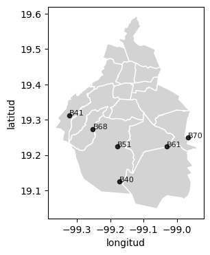

```python
# graficar muestras en el mapa
fig, ax= plt.subplots(1,1, figsize=(4,4))

burshp.plot(ax=ax, color='lightgrey', edgecolor='white', linewidth=1)

# plot points
smd.plot(x="longitud", y="latitud", kind="scatter", c='black', alpha=0.8, s=20, ax=ax)

# annotate points
for _,crow in smd.iterrows():
    ax.text(crow['longitud'], crow['latitud'], crow['id'], fontsize=8, alpha=0.9)
```

```python
import skbio
```

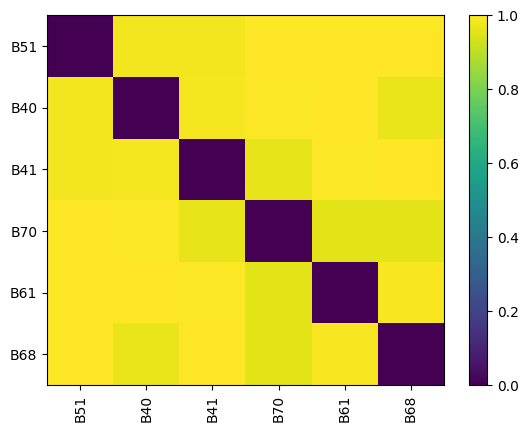

```python
# calcular diversidad beta
dbeta = skbio.diversity.beta_diversity('braycurtis', otu)
dbeta.plot();
```

```python
# para calcular diatancias geograficas cambiamos a valores absolutos
np.abs(smd[['longitud','latitud']])
```

| id | longitud | latitud |
| --- | --- | --- |
| B40 | 99.172 | 19.125 |
| B41 | 99.323 | 19.313 |
| B51 | 99.179 | 19.224 |
| B61 | 99.031 | 19.224 |
| B68 | 99.252 | 19.274 |
| B70 | 98.966 | 19.249 |

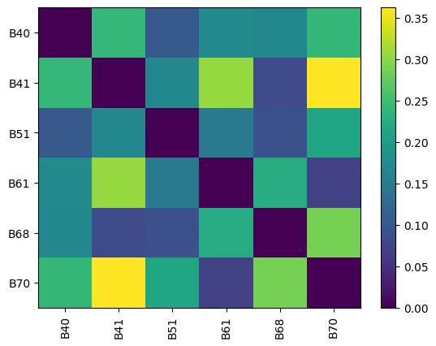

```python
# obtener distancias geograficas
dgeo = skbio.diversity.beta_diversity('euclidean', np.abs(smd[['longitud','latitud']]))
dgeo.plot();
```

```python
dbeta
```

```
<skbio.stats.distance._base.DistanceMatrix at 0x7e136cbe7220>
```

```python
norder
```

```
['B40', 'B41', 'B51', 'B61', 'B68', 'B70']
```

```python
# ordenar matrices

norder = sorted(dbeta.ids)
dbeta = dbeta.filter(norder)
dgeo = dgeo.filter(norder)
```

```python
# mantel test
skbio.stats.distance.mantel(dbeta, dgeo, method='spearman', permutations=1000, alternative='two-sided')
```

```
(np.float64(-0.15412285378752058), np.float64(0.6013986013986014), 6)
```

## Finalizar

- Descagar HTML dando click en "File" luego en "Save and export notebook as" y elegir "HTML"
- Abrir el archivo descargado en un navegador web

Recordar que:

- Corregir errores ayuda a entender el ecosistema de trabajo
- Documentar permite repetir y compartir
- Montar análisis puede ser tedioso pero permite tener un catálogo de análisis repetibles